# ffnn_1_lab

### Exercises

**function exploration**

Use your code for the 2-layer neural network to explore how the number of neruons in the hidden layer affects the function that the neural network implements. Vary the number of hidden neurons between say 1 and 20 and look at a few example networks for each. Plot some results for various values.

How does the number of hidden units effect the function that your neural net represents? Explain why this is is this?

What range of outputs seems to be acheivable? Why is this? What kind of supervised learning task would this network be suited for because of this?

Type your answer in a text box below.

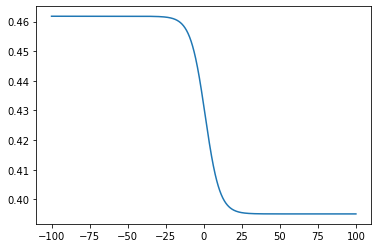

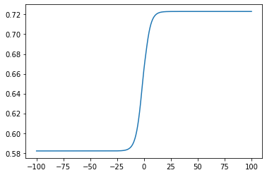

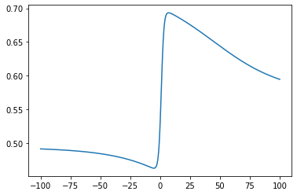

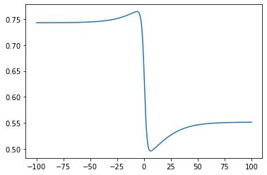

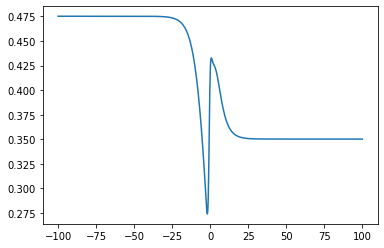

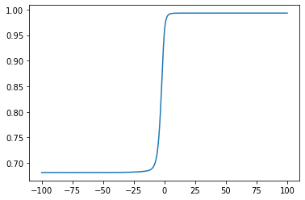

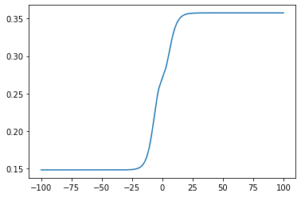

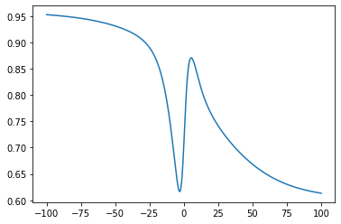

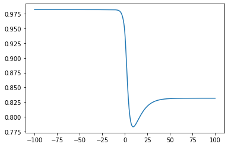

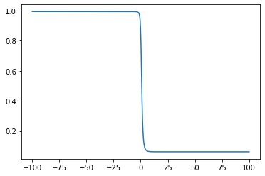

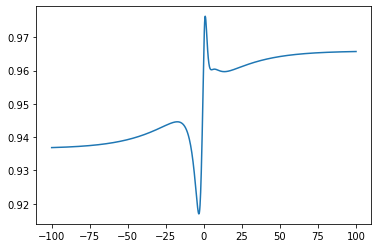

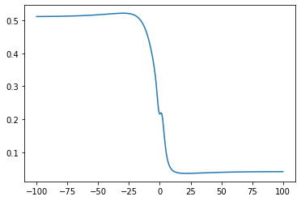

[8 more figures not shown]

```python
# Set the input dimension, the number of hidden units, and the number of ouptput units
n_input,n_output = 1,1
n_hidden = list(np.arange(1,21))
# We want get the NN's output for a range of input values, so that we cant plot
# input vs output. We can get evenly space values using `np.linspace`. We also
# want to process these inputs as a "batch", so we use `np.newaxis` to turn this
# 1-d array into a 2-d array with a single column.
n_grid = 1000
x_left, x_right = -100, 100
X = np.linspace(x_left, x_right, n_grid)[:, np.newaxis]

# We can generate random values (drawn from a standard gaussian distribution --
# mean = 0, standard deviation = 1), with `np.random.randn(shape)`
for i in range(0,20):
    W_1 = np.random.randn(n_input, n_hidden[i])
    b_1 = np.random.randn(n_hidden[i])
    W_2 = np.random.randn(n_hidden[i], n_output)
    b_2 = np.random.randn(n_output)

# Use our NN to compute the outputs for these inputs
    Y_hat = nn_two_layers(X, W_1, b_1, W_2, b_2)

# Plot the input values (x-axis) against the output values (y-axis)
    plt.plot(X, Y_hat)
    plt.show()
```

```python
# As the number of hidden units increase, the plots will be more complex. It is because with the increasment of the hidden layers, the original input will have more changes, and the output value may be more complex.
# The range of the output can be 0 to 1, because the sigmoid function has exponent, so the output cannot less than 0, also the 1/(1+exp(x)) will not allow the output more than 1.
# Logistic regression has the similar range of output, so it may be suitable.
```

**deep neural nets**

Our neural network currently works for only a single hidden layer. This is a rather shallow network, and the next step is to extend it to a deep network that can handle any number of layers.

To handle an arbitrary number of layers, switch to taking a 3-dimensional array for the layer weights -- now the first index will specify which layer the remaing 2-dimension subarray is associated with (e.g. `W[2]` would be the 2-d array of weights for the connections from layer 2 to layer 3). Similary, add another dimension to the biases to specify the layer, making $b$ a 2-dimensional array.

Here you will probably need to use a for loop to iterate through the layers. You can continue to use the sigmoid activation function for all layers.

```python
def deep_nn(X, W, b):
  '''
  forward pass for a deep neural net with an arbitrary number of layers

  parameters
  ----------
  X (2d array):     input vectors
  W (3d array):     weight matrices -- W[layer, input, neuron]
  b (2d array):     biase vectors -- b[layer, neuron]
  '''
  h = nn_layer(X,W[0],b[0])
  for i in range(1,len(W)):
     h = nn_layer(h,W[i],b[i])
  return h
```

```python
X = [
     [0, 0, 0],
     [1, 1, 1],
     [-1, 0, 1]
]
W = [[
     [0, 1, 0],
     [0, 1, 1],
     [0, 1, 2]
],[[0, 1, 0],
     [0, 1, 1],
     [0, 1, 2]]]
b = [[0, 0, 0],[1,1,1]]
deep_nn(X, W, b)
```

```
array([[0.73105858, 0.92414182, 0.92414182],
       [0.73105858, 0.96786504, 0.97932063],
       [0.73105858, 0.94688896, 0.9630875 ]])
```